# Text Mining Leadership Survey: Topic Models (with covariates)

Oct 30, 2017

## Reload Previous Image

### Load the image

We’ll first start to reload our data that was completed after part 1.

See the code from part 1 to understand how the data was created.

```r
load("01-datacleaning-exploration.RData")
```

## Structural Topic Modeling

### Baseline Model

Let’s run (structural) topic modeling using the `stm` package.

First, we’ll need to call the `stm` package. If you do not have the package, run the command `install.packages("stm")` to install the package.

Before running stm, we’ll need to convert the dfm (based on the `quanteda` package) to the data structure that stm uses through the `convert` function.

Last, we’ll create a data structure (`out`) that includes our data structure, the words and the metadata (covariates).

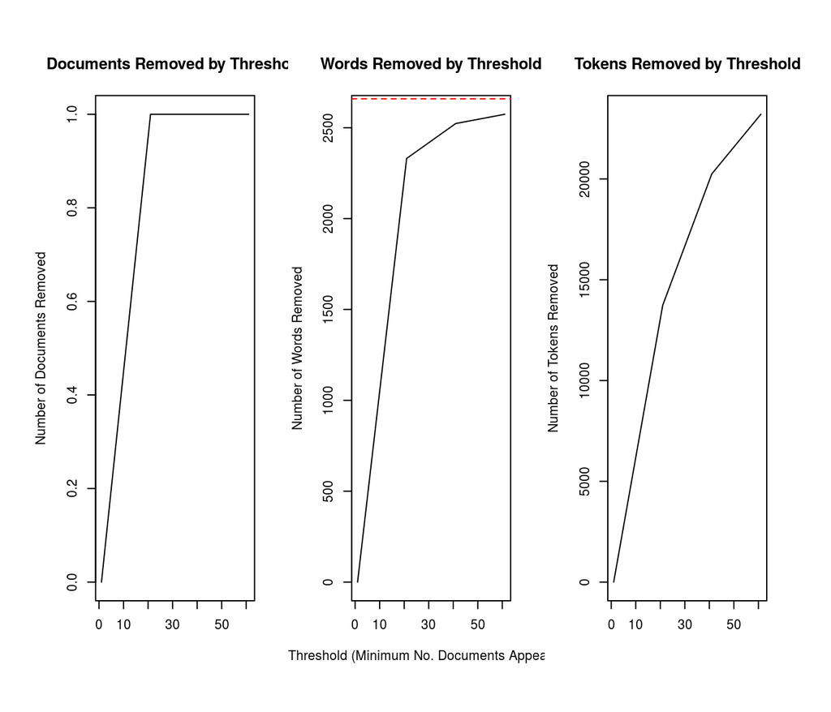

```r
library(stm)
library(quanteda)

# use quanteda converter to convert our Dfm
stmdfm <- convert(dfm, to = "stm", docvars = docvars(myCorpus))

plotRemoved(stmdfm$documents, lower.thresh = seq(1, 80, by = 20))
```

```r
out <- prepDocuments(stmdfm$documents, stmdfm$vocab, stmdfm$meta, lower.thresh = 3)
```

```
## Removing 1175 of 2659 terms (2764 of 33277 tokens) due to frequency
## Your corpus now has 1170 documents, 1484 terms and 30513 tokens.
```

#### Run the baseline model:

For this example, we will include five topics for the sake of parsimony. Review part 2 to consider ways to run validations on the number of topics.

Let’s run the model with two covariates: country and occupation. We will pass them through the `prevalence` parameter using a “+” to link both values.

```r
k <- 5

stmFit <- stm(out$documents, out$vocab, K = k, prevalence = ~Country + Occupation,
    max.em.its = 150, data = out$meta, init.type = "Spectral", seed = 300)
```

We can then plot the topic summaries…

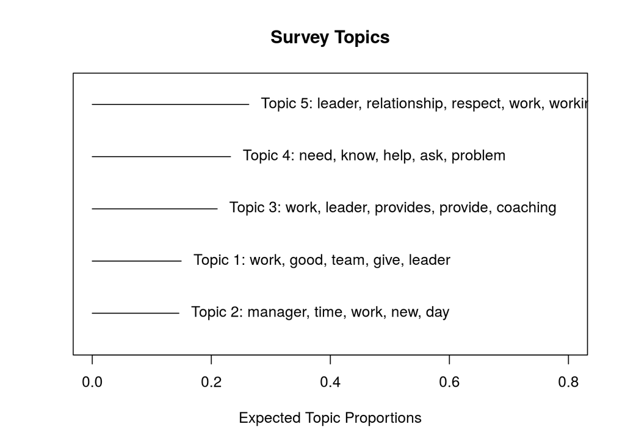

```r
plot(stmFit, type = "summary", xlim = c(0, 0.8), ylim = c(0.4, k + 0.4), n = 5, main = "Survey Topics",
    width = 10, text.cex = 1)
```

…as well as save information about the topics that will make it easier to identify them later on.

```r
topicNames <- labelTopics(stmFit)
topic <- data.frame(topicnames = paste0("Topic ", 1:k), TopicNumber = 1:k, TopicProportions = colMeans(stmFit$theta))
```

#### Topic Labels

For this, we’ll plot the 20 words that best describe each topic. First, we’ll plot each topic (each “row”) using two measures: the topic probability (left column) and the FREX (right column).

The left column of topics show the words based on the typical topic model output: word-topic probabilities. Also, we’ll use the FREX that reweights the word-topic probabilities to emphasize the words that are more “frequent” and more “exclusive” for each topic (hence “FR” + “EX”). For more details on FREX, see page 5 of [Roberts et al. (2013)](http://scholar.harvard.edu/dtingley/files/topicmodelsopenendedexperiments.pdf).

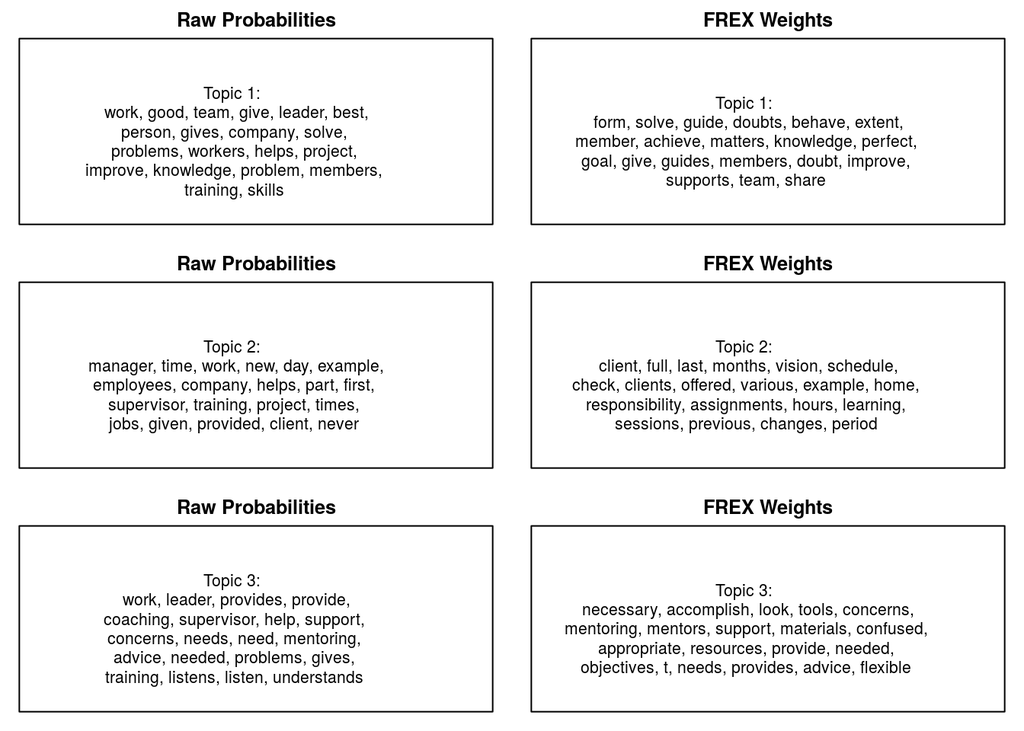

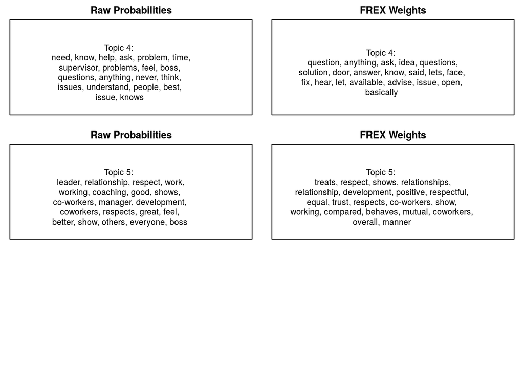

```r
par(mfrow = c(3, 2), mar = c(1, 1, 2, 1))
for (i in 1:k) {
    plot(stmFit, type = "labels", n = 20, topics = i, main = "Raw Probabilities",
        width = 40)
    plot(stmFit, type = "labels", n = 20, topics = i, main = "FREX Weights", labeltype = "frex",
        width = 50)
}
```

Ultimately, our goal is to give names (labels) for each topic. We’ll then use those labels instead of calling each by its number (which is essentially meaningless). Typically, the first couple of words in the FREX scores provide ideal one or two-word names for the topics. We’ll need to decide on the labels as a group and (ideally) with names that are consistent with any theoretical frameworks you’re aware of with respect to leadership.

We can also manually output the top words for each topic using the word probabilities (“Highest Prob”), FREX and two other measurements (Lift and Score). Let’s consider topic 3.

```r
labelTopics(stmFit, 3)
```

```
## Topic 3 Top Words:
##       Highest Prob: work, leader, provides, provide, coaching, supervisor, help
##       FREX: necessary, accomplish, look, tools, concerns, mentoring, mentors
##       Lift: t, mentors, profession, zero, confused, unfortunately, outs
##       Score: profession, mentoring, needs, concerns, support, necessary, provide
```

```r
shortdoc <- substr(text, 1, 300)
findThoughts(stmFit, texts = shortdoc, n = 5, topics = 3)
```

```
##
##  Topic 3:
##       My leader provides appropriate and necessary training
## They always look up to me when any work is needed to be done  I always look up t them when I am confused
## Yes we do have tenured mentors
## My leader provides appropriate and necessary training
## They always look up to me when any work is needed to
##      My leader provides appropriate and necessary training
## They always look up to me when any work is needed to be done
## Both are same
## My leader provides appropriate and necessary training
## They always look up to me when any work is needed to be done
## Both are same
## My leader provides appropriate and n
##      My supervisor tends to provide an adequate amount of support to me to accomplish my work objectives  He listens to my concerns and gives appropriate advice  He provides adequate coaching and mentoring most of the time  My supervisor tends to provide an adequate amount of support to me to acc…
##      When I was hired in to my organization, I made it very clear to my leader that I had ambitions to go higher in the company  However, in order for me to go beyond my current position, I would have to take my leader's current position  My leader listens to my concerns as far as the productivit…
##      He seems to really understand my problems and needs  He gives me support when I need it, to help me accomplish my objectives in work  He listens to my concerns and provides advice  He gives me coaching and mentoring when necessary  He gets stressed at times, but always seems to go out of his…
```

In the case of topic 3, we can give this topic the label “Provides Support” as it seems the major words are “provide(s)”, “coaching”, “mentors” and “help”.

We can give all the topics labels by following the same procedure for each. To rename the topics, use the following code.

```r
topicNames <- labelTopics(stmFit)
topic <- data.frame(topicnames = c("Problem Solving", "Time Management", "Provides Support",
    "Ask Questions", "Shows Respect"), TopicNumber = 1:k, TopicProportions = colMeans(stmFit$theta),
    stringsAsFactors = F)
```

#### Interpretability

We can also use the Semantic Coherence and Exclusivity to measure the interpretability of each topic.

```r
topicQuality(stmFit, documents = out$documents)
```

```
## [1]  -89.33452 -103.31324  -66.73870  -82.30216  -68.31779
## [1] 8.917431 8.455931 9.179232 8.720536 8.759805
```

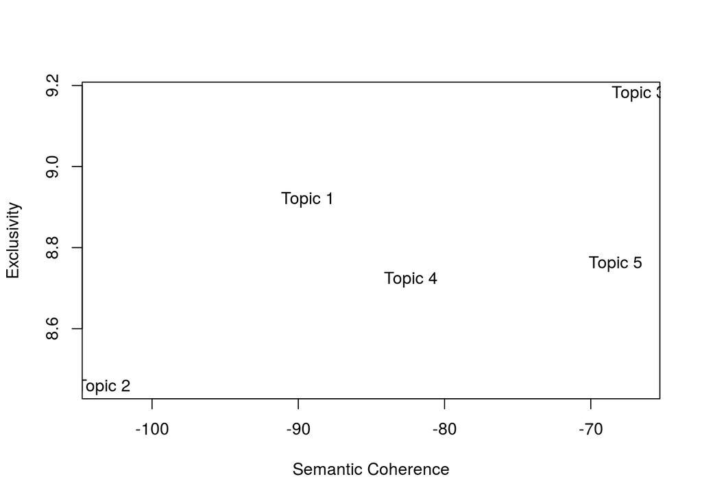

Essentially, topics that have a higher (i.e. more right on the x-axis) tend to be interpretable. On the other hand, topics on the left have a lower semantic coherence. This sometimes can be because that topic is a mixture of two or more sub-topics. This topic may separate if we moved to 6 topics. This is important when we run inference and need to interpret the results.

#### Topic Comparisons

We can also examine the relationships between topic words visually using the `plot.STM’ perspectives plots.

For example, we can compare the words used for topic 1 and topic 3.

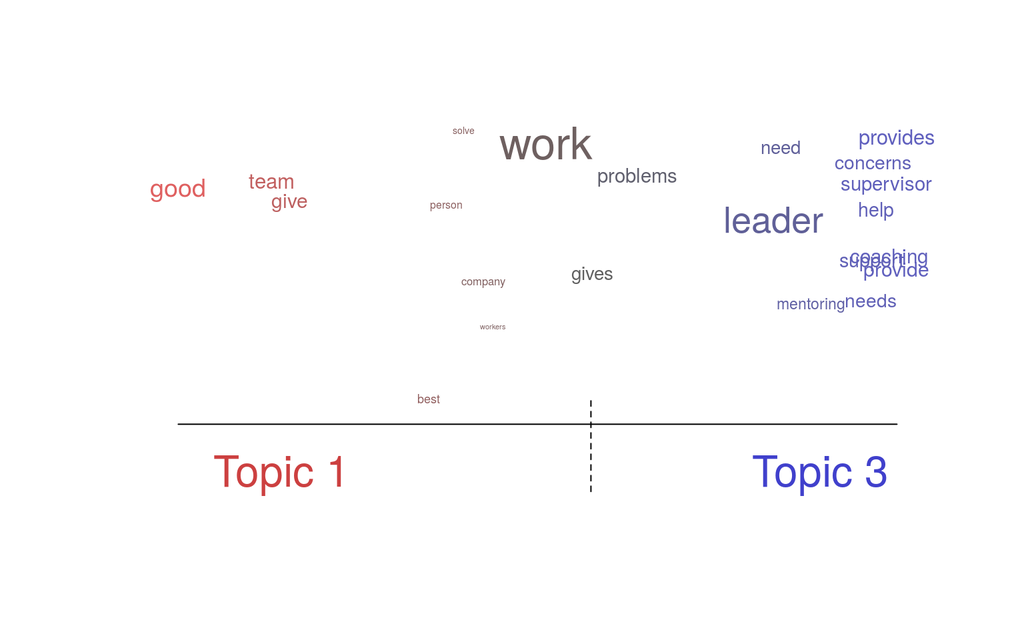

```r
plot(stmFit, type = "perspectives", topics = c(1, 3))
```

Note that the words that are in the middle are shared by these topics whereas words near the left or right side are more unique to the topic (relative to the other topic).

## Covariate Analysis

Next, let’s examine the effects country and occupation have on the topic proportions.

### Effect of Country

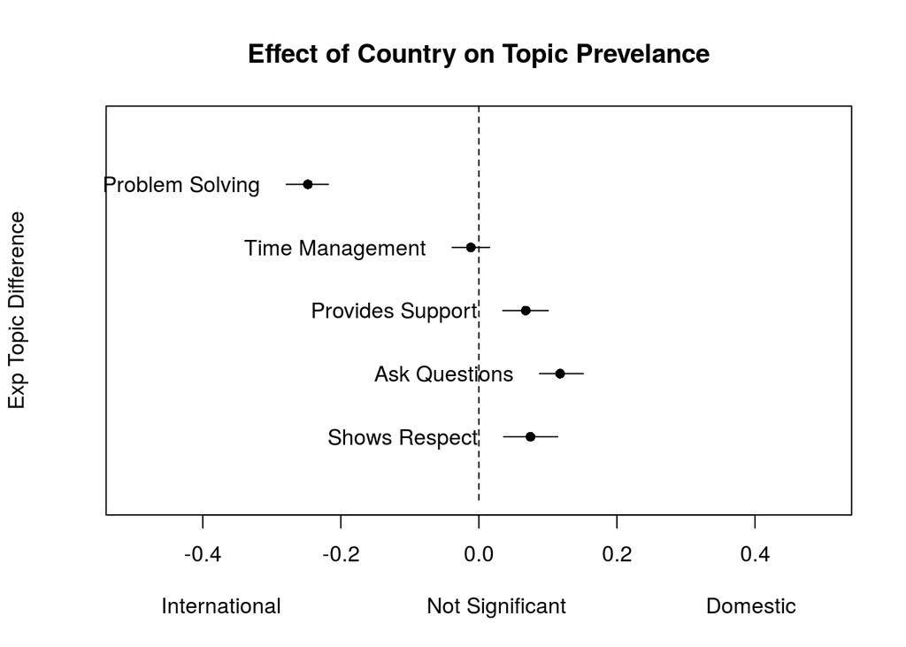

```r
Result <- plot(prep, "Country", method = "difference", cov.value1 = "Domestic", cov.value2 = "International",
    verbose.labels = F, model = stmFit, labeltype = "custom", custom.labels = topic$topicnames,
    ylab = "Exp Topic Difference", xlab = "International                        Not Significant                       Domestic",
    main = "Effect of Country on Topic Prevelance", xlim = c(-0.5, 0.5), width = 40,
    ci.level = 0.95)
```

Alternatively, we can reorder the coefficients by their rank to aid in intrepretating the visualization.

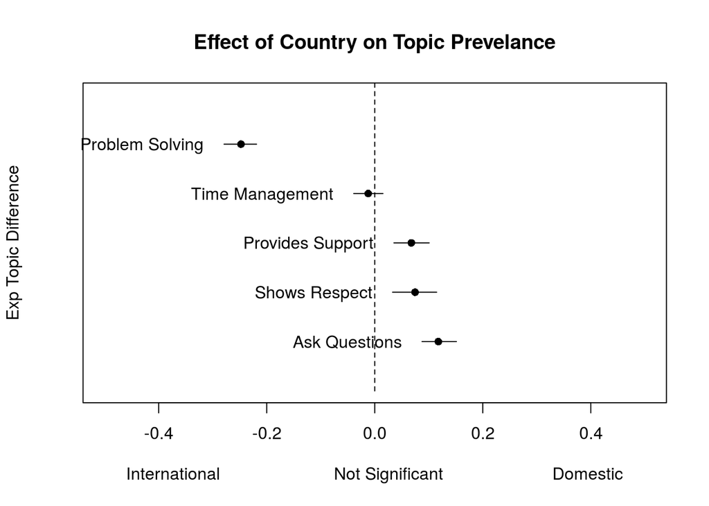

```r
# order based on Expected Topic Proportion
trank = order(unlist(Result$means))
temp.topic <- topic[trank, ]

x <- plot(prep, "Country", method = "difference", cov.value1 = "Domestic", cov.value2 = "International",
    verbose.labels = F, topics = temp.topic$TopicNumber, model = stmFit, labeltype = "custom",
    custom.labels = temp.topic$topicnames, ylab = "Exp Topic Difference", xlab = "International                        Not Significant                       Domestic",
    main = "Effect of Country on Topic Prevelance", xlim = c(-0.5, 0.5), width = 40,
    ci.level = 0.95)
```

The way we can interpret this is that international respondees discussed the issue of problem solving much more significantly than domestic respondees. Alternatively, domestic respondees discussed topics on “providing support”, “respect”, and “asking questions” more prevalently than International respondees.

### Effect of Occupation

We can plot the effect of Occupation. Since this field has three categories, we need to run as two binary columns. We’ll use “Entry Level” as the baseline.

#### Entry Level vs Analyst

First, let’s examine the relationship between “Entry Level” and “Analyst”:

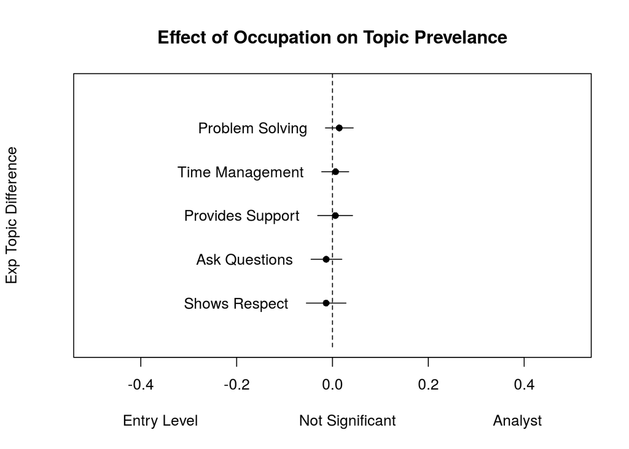

```r
Result <- plot(prep, "Occupation", method = "difference", cov.value1 = "Analyst",
    cov.value2 = "Entry Level", verbose.labels = F, model = stmFit, labeltype = "custom",
    custom.labels = topic$topicnames, ylab = "Exp Topic Difference", xlab = "Entry Level                        Not Significant                       Analyst",
    main = "Effect of Occupation on Topic Prevelance", xlim = c(-0.5, 0.5), width = 40,
    ci.level = 0.95)
```

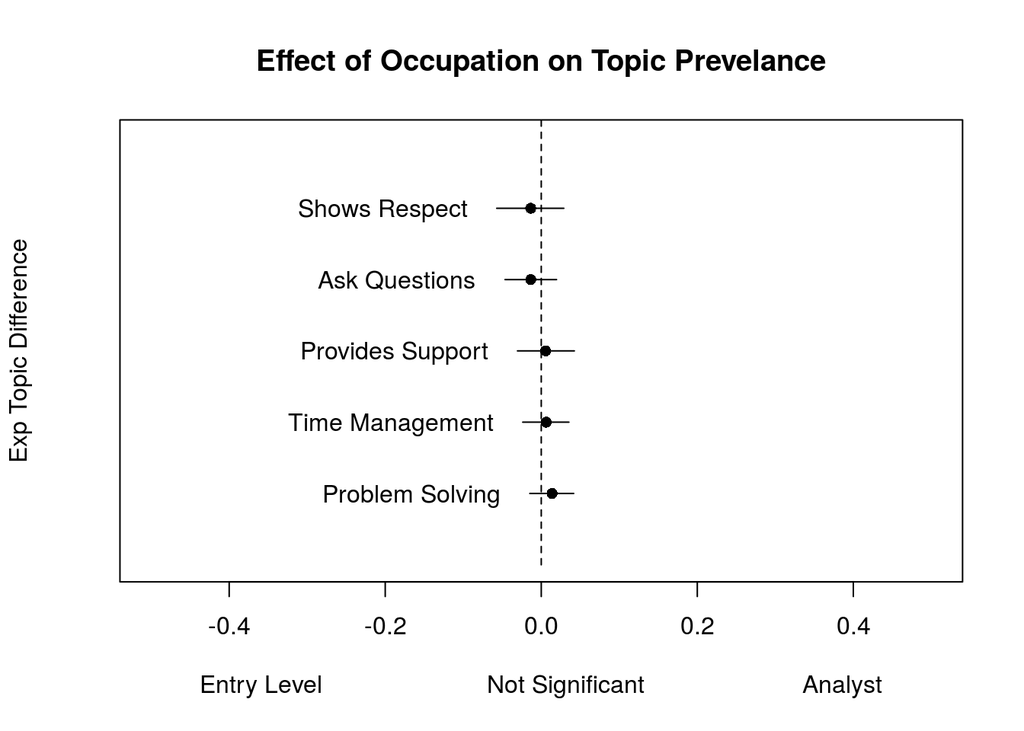

```r
# order based on Expected Topic Proportion
orank = order(unlist(Result$means))
temp.topic <- topic[orank, ]

x <- plot(prep, "Occupation", method = "difference", cov.value1 = "Analyst", cov.value2 = "Entry Level",
    verbose.labels = F, topics = temp.topic$TopicNumber, model = stmFit, labeltype = "custom",
    custom.labels = temp.topic$topicnames, ylab = "Exp Topic Difference", xlab = "Entry Level                        Not Significant                       Analyst",
    main = "Effect of Occupation on Topic Prevelance", xlim = c(-0.5, 0.5), width = 40,
    ci.level = 0.95)
```

In this example, we do not find a significant difference in the topics discussed by either entry level or analyst-level participants.

Next, let’s consider “Entry Level” vs “Management”:

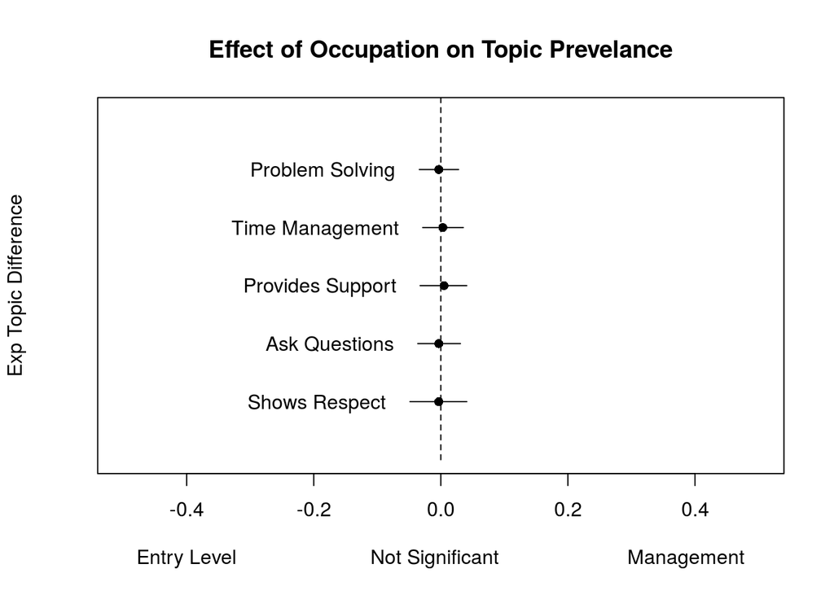

```r
Result <- plot(prep, "Occupation", method = "difference", cov.value1 = "Management",
    cov.value2 = "Entry Level", verbose.labels = F, model = stmFit, labeltype = "custom",
    custom.labels = topic$topicnames, ylab = "Exp Topic Difference", xlab = "Entry Level                        Not Significant                       Management",
    main = "Effect of Occupation on Topic Prevelance", xlim = c(-0.5, 0.5), width = 40,
    ci.level = 0.95)
```

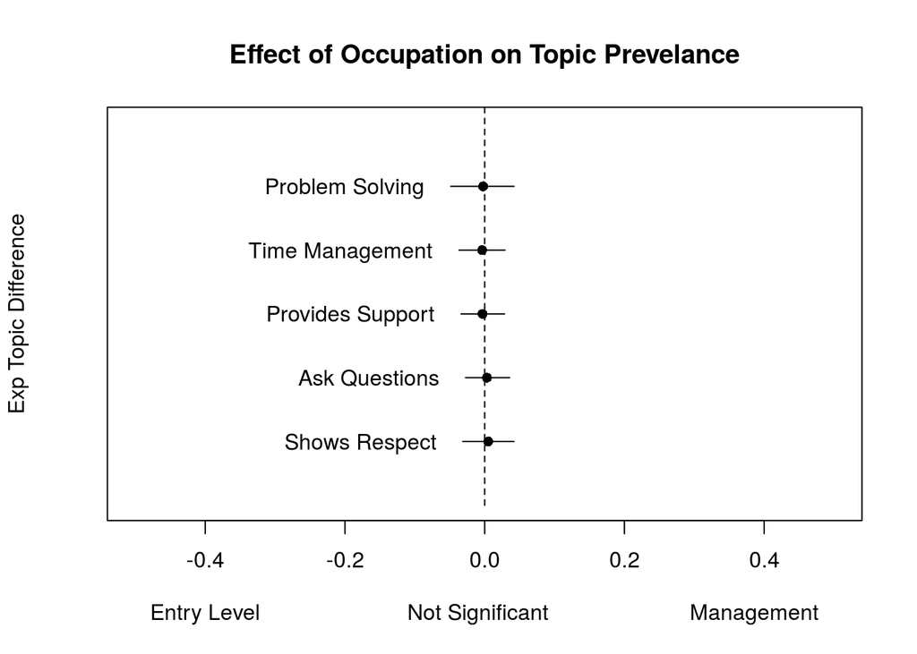

```r
# order based on Expected Topic Proportion
orank = order(unlist(Result$means))
temp.topic <- topic[orank, ]

x <- plot(prep, "Occupation", method = "difference", cov.value1 = "Management", cov.value2 = "Entry Level",
    verbose.labels = F, topics = temp.topic$TopicNumber, model = stmFit, labeltype = "custom",
    custom.labels = topic$topicnames, ylab = "Exp Topic Difference", xlab = "Entry Level                        Not Significant                       Management",
    main = "Effect of Occupation on Topic Prevelance", xlim = c(-0.5, 0.5), width = 40,
    ci.level = 0.95)
```

We find the same result for Entry Level versus Management. Essentially, we cannot find evidence that the role (occupation) had a significant effect on the topics discussed.

### Effect of Gender

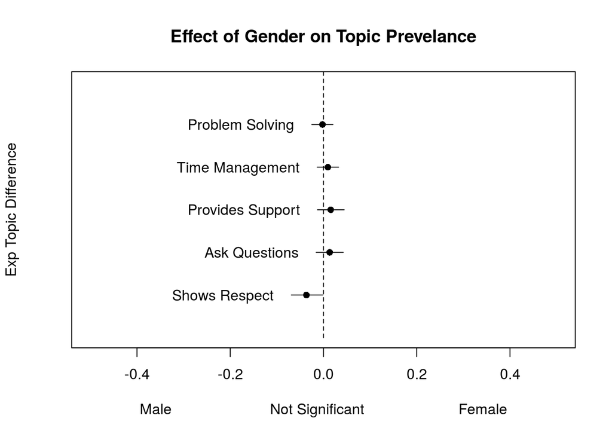

```r
genderResult <- plot(prep2, "SelfGender", method = "difference", cov.value1 = "Female",
    cov.value2 = "Male", verbose.labels = F, model = stmFit, labeltype = "custom",
    custom.labels = topic$topicnames, ylab = "Exp Topic Difference", xlab = "Male                        Not Significant                       Female",
    main = "Effect of Gender on Topic Prevelance", xlim = c(-0.5, 0.5), width = 40,
    ci.level = 0.95)
```

### Effect of Manager’s Gender

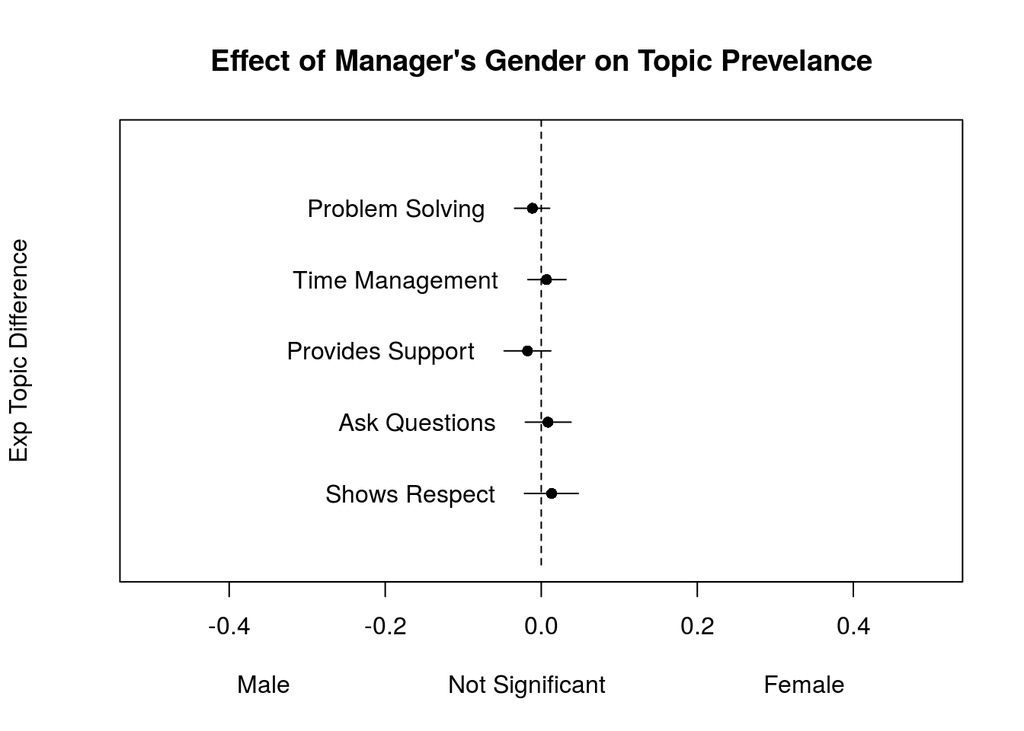

```r
mgrgenResult <- plot(prep2, "ManagerGender", method = "difference", cov.value1 = "Female",
    cov.value2 = "Male", verbose.labels = F, model = stmFit, labeltype = "custom",
    custom.labels = topic$topicnames, ylab = "Exp Topic Difference", xlab = "Male                       Not Significant                       Female",
    main = "Effect of Manager's Gender on Topic Prevelance", xlim = c(-0.5, 0.5),
    width = 40, ci.level = 0.95)
```

```r
save.image(file = "03-topicmodel-covariates.RData")
```